# Fundamentos de genética de poblaciones

Curso Genética y Genómica en Producción Animal

Dr. José A. Gallardo.

Profesor adjunto de la Pontificia Universidad Católica de Valparaíso.  
jose.gallardo@pucv.cl

April 15, 2021

### OBJETIVO

El objetivo del trabajo práctico es comprender principios fundamentales de la genética de poblaciones usando la librería **learnPopGen**.

Específicamente se simularán distintos procesos sistemáticos y dispersivos que modifican la frecuencia de los genes incluyendo, la deriva genética, la selección y la migración.

### INTRODUCCIÓN LIBRERÍA learnPopGen.

La librería **learnPopGen** (Revell et al. 2019) permite realizar análisis numérico y simulaciones con el propósito de comprender principios básicos de genética de poblaciones y evolución.

Funciones clave

**genetic.drift()**: This function simulates genetic drift at a biallelic genetic locus with no selection and no mutation in a sexually reproducing diploid population or set of populations.

**founder.event()**: This function simulates genetic drift with a founding event / population bottleneck at time etime.

**selection()**: This function performs numerical analysis of a simple biallelic selection model.

**msd**: Simulates migration, natural selection, and genetic drift. Selection can be in opposite directions in the two populations experiencing gene flow.

### INSTRUCCIONES GENERALES

1.- Resuelva los ejercicios propuestos en el siguiente proyecto colaborativo de Rstudio cloud [Genetica poblacional](https://rstudio.cloud/spaces/132848/project/2436414).

2.- Para cada ejercicio cree un bloque de códigos diferente y use **set.seed(123)** para los resultados sean comparables.

3.- Compile el código con el botón Knit y guardelo en formato html.

4.- Comparta su reporte en la carpeta Drive de la [clase 3](https://drive.google.com/drive/folders/1XqTP8SZv5MtcHUXHKEhQLAT6X_AUfYFc?usp=sharing)

### ACTIVIDADES

**Actividad 1.** DERIVA GENÉTICA

1. Compare el cambio en la frecuencia de los genes entre una población con tamaño reducido (Ne = 20) y otra con elevado tamaño poblacional (Ne = 1000). Suponga que la frecuencia inicial del gen p = 0.5 y que el número de generaciones es de 50.

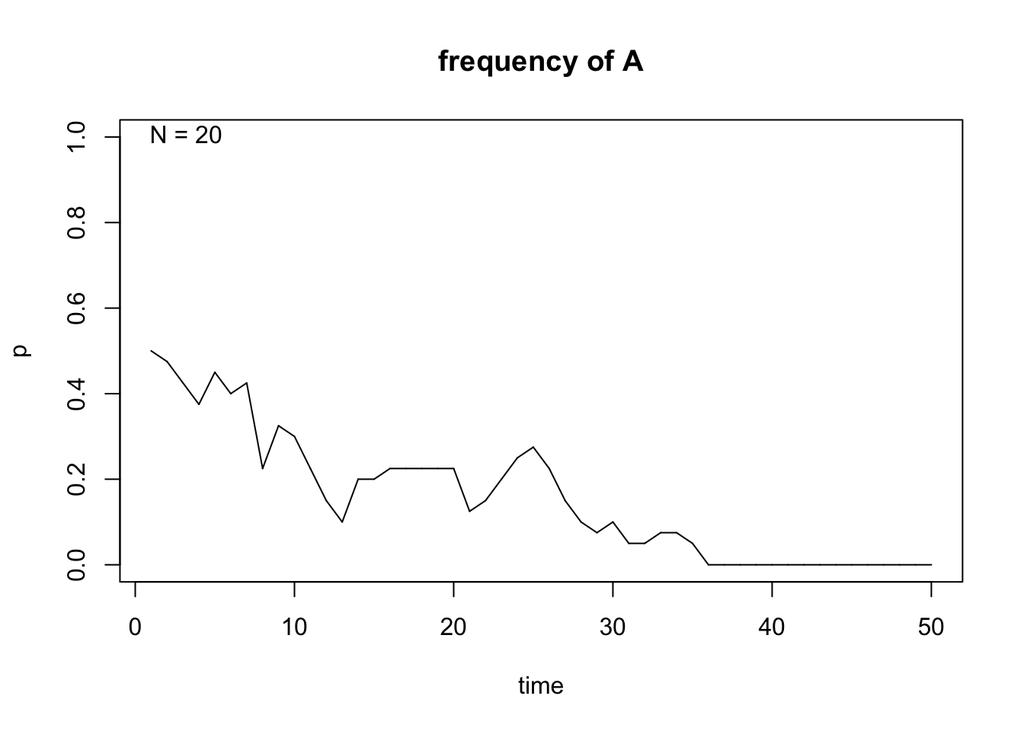

```r
set.seed(123)

genetic.drift(p0=0.5, Ne=20, nrep=1, time=50, show="p")
```

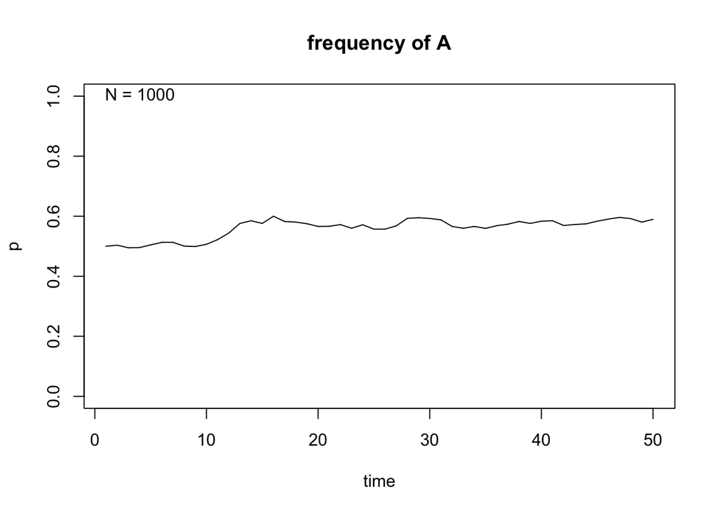

```r
genetic.drift(p0=0.5, Ne=1000, nrep=1, time=50, show="p")
```

2. Compare el cambio en la frecuencia de los genes entre 4 poblaciones con tamaño reducido (Ne = 20). Suponga que la frecuencia inicial del gen p = 0.5 y que el número de generaciones es de 50.

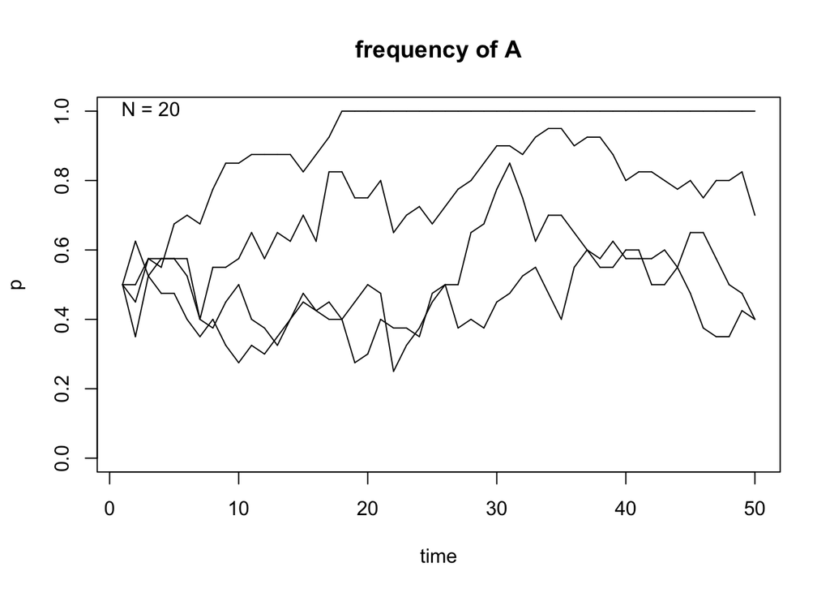

Simulación Deriva genética sobre cuatro poblaciones independientes cuyo tamáno efectivo de la poblacion (Ne) es 20

```r
set.seed(123)
genetic.drift(p0=0.5, Ne=20, nrep=4, time=50, show="p")
```

3. Interprete sus resultados del ejercicio a y b.

**Actividad 2.** DERIVA GENÉTICA: EFECTO FUNDADOR.

1. Compare el cambio en la frecuencia de los genes entre 4 islas diferentes que son colonizadas a partir de una misma población de origen.

Simula una población de origen con 10.000 individuos, pero de los cuales solo 10 aerán los fundadores en cada isla. Suponga que la frecuencia inicial del gen p = 0.5 en la población de origen, que el número de generaciones es de 10 y que la colonización ocurre en la generación 5.

```r
set.seed(123)

par(mfrow = c(2, 2))

f1<- founder.event(show="p", p0=0.5, Ne=10000, Nf=10, ttime=10, etime=5)
f2<- founder.event(show="p", p0=0.5, Ne=10000, Nf=10, ttime=10, etime=5)
f3<- founder.event(show="p", p0=0.5, Ne=10000, Nf=10, ttime=10, etime=5)
f4<-founder.event(show="p", p0=0.5, Ne=10000, Nf=10, ttime=10, etime=5)
```

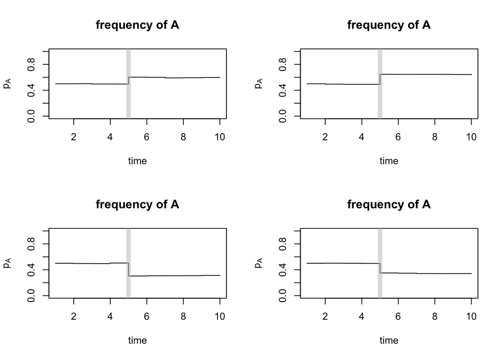

**Actividad 3.** SELECCIÓN: ALELO DOMINANTE RESISTENTE A LOS ANTIPARASITARIOS.

En este ejercicio simule una población de parásitos en la cual se origina, por mutación, un alelo resistente “A” contra los antiparasitarios que es dominante sobre la versión susceptible “a”.

El alelo resistente duplica en fitness (w=1) al alelo recesivo (w=0,5), como podría ocurrir por ejemplo cuando en la industria animal de producción de carne se hace uso intensivo de antiparasitarios para el tratamiento de enfermedades. Por lo tanto, la relación de genotipos y fitness es como se observa en la siguiente tabla.

```r
Genotype <- c("AA", "Aa", "aa")

Fitness<- c(1.0,1.0,0.5)

sel<- data.frame(Genotype, Fitness)
 knitr::kable(
  sel,
  caption = "Fitness de genotipos 2 resistentes (AA y Aa) y uno susceptible a antibióticos (aa) en una población de parásitos patógenos de animales.")
```

Fitness de genotipos 2 resistentes (AA y Aa) y uno susceptible a antibióticos (aa) en una población de parásitos patógenos de animales.

| Genotype | Fitness |
| --- | --- |
| AA | 1.0 |
| Aa | 1.0 |
| aa | 0.5 |

Considere finalmente, que la frecuencia incial del alelo resistente que aparece por mutación “A” será de 0,01. Use el argumento show=“p” y show=“q” para comparar el cambio de cada alelo.

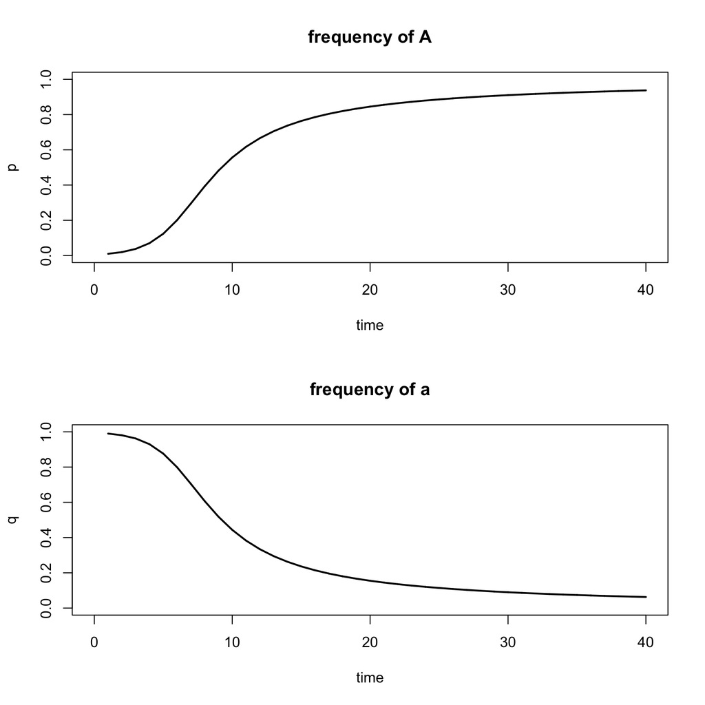

Simulación de la selección actuando a favor de un gen de resistencia contra antiparasitarios en una población de parásitos

```r
par(mfrow = c(2, 1))

selection(p0=0.01, w=Fitness, time=40, show="p", pause=0.1)
selection(p0=0.01, w=Fitness, time=40, show="q", pause=0.1)
```

**TAREA**

**1.-** Respecto del ejemplo de selección de un alelo resistente a los antiparasitarios. Simule el cambio en la frecuencia de los genes en las siguientes circunstancias:

1. El heterocigoto Aa tiene un fitness de 0,75. Mantenga los otros fitness como en el ejercicio.
2. El heterocigoto tiene un fitness de 0,5.
3. Interprete y compare sus resultados de a y b con lo observado en el ejercicio de alelo resistente.

**2.-** Respecto del ejercicio de deriva génica por efecto fundador. Simule el cambio en la frecuencia de los genes en las siguientes circunstancias:

1. Población inicial 1.000 y 100.000. Mantenga los otros parametros.
2. Frecuencia del alelo p= 0,9 y p= 0,1. Mantenga los otros parametros.
3. Interprete y compare sus resultados de a y b con lo observado en el ejercicio de efecto fundador.

3.- La migración, la selección y la deriva genética pueden actuar de forma combinada. Simule mediante la función **msd** (Migración, selección y deriva, de la librería learnPopGen) el fenomeno de migración y deriva en las siguientes circunstancias:

1. Migración de la población 1 a la población 2 con una tasa de migración del 0,1 %, 1 % y 5 %. Suponga que ambas poblaciones son pequeñas Ne=100 y que la frecuencia inicial de los genes son p0 (pop1)= 0,9 y p0 (pop2) = 0,1. El fitness de los 3 genotipos de ambas poblaciones es 1, es decir no hay selección. Considere 400 generaciones.
2. Usando el mismo ejercicio anterior, ahora considere un efecto de selección en contra del alelo p en la población 2 ( w=c(0.1, 1, 1)).
3. Interprete y compare sus resultados de a y b.

### REFERENCIAS

**Revell L.J.**. learnPopGen: An R package for population genetic simulation and numerical analysis. 2019. Ecology and Evolution Volume 9, Issue 14. https://doi.org/10.1002/ece3.5412